# SOLUTIONS: Estimating the smoking effect on FEV

Effect sizes, confounding, and prediction

GRAPH Courses team

2026-07-09

# Introduction

In a previous workshop, we used a dataset of forced expiratory volume (FEV) from East Boston in the 1970s to learn about the uses of regression: describing relationships, predicting outcomes, and controlling for another variable.

In this workshop, we revisit that dataset to again look at the relationship between smoking and FEV. Our goal is to answer the question: what is the adjusted association between smoking and FEV in children and adolescents? Because these are observational data, we will use association language rather than claiming a causal effect.

## Dataset description

The dataset contains 654 youths aged 3 to 19 from East Boston in the 1970s. The outcome is **forced expiratory volume** (`fev_l`), measured in litres. Higher values mean better lung function.

# Load packages and data

Use `p_load()` to load `tidyverse`, `here`, `modelsummary`, and `equatiomatic`. The GitHub line below loads `inspectdf`.

*Exercise chunk (blank):*

```r
if (!require(pacman)) install.packages("pacman")
pacman::p_load(________)
pacman::p_load_gh("the-graph-courses/inspectdf")
```

**Solution:**

```r
if (!require(pacman)) install.packages("pacman")
pacman::p_load(tidyverse, here, modelsummary, equatiomatic)
pacman::p_load_gh("the-graph-courses/inspectdf")
```

Now, glimpse, then inspect the data with the inspect_cat() and inspect_num() functions from inspectdf.

```r
fev <- read_csv(here("data/fev_kahn.csv"))
glimpse(fev)
```

```
## Rows: 654
## Columns: 5
## $ age_yrs   <dbl> 9, 8, 7, 9, 9, 8, 6, 6, 8, 9, 6, 8, 8, 8, 8, 7, 5, 6, 9, 9, …
## $ fev_l     <dbl> 1.708, 1.724, 1.720, 1.558, 1.895, 2.336, 1.919, 1.415, 1.98…
## $ height_in <dbl> 57.0, 67.5, 54.5, 53.0, 57.0, 61.0, 58.0, 56.0, 58.5, 60.0, …
## $ sex       <chr> "female", "female", "female", "male", "male", "female", "fem…
## $ smoke     <chr> "non_smoker", "non_smoker", "non_smoker", "non_smoker", "non…
```

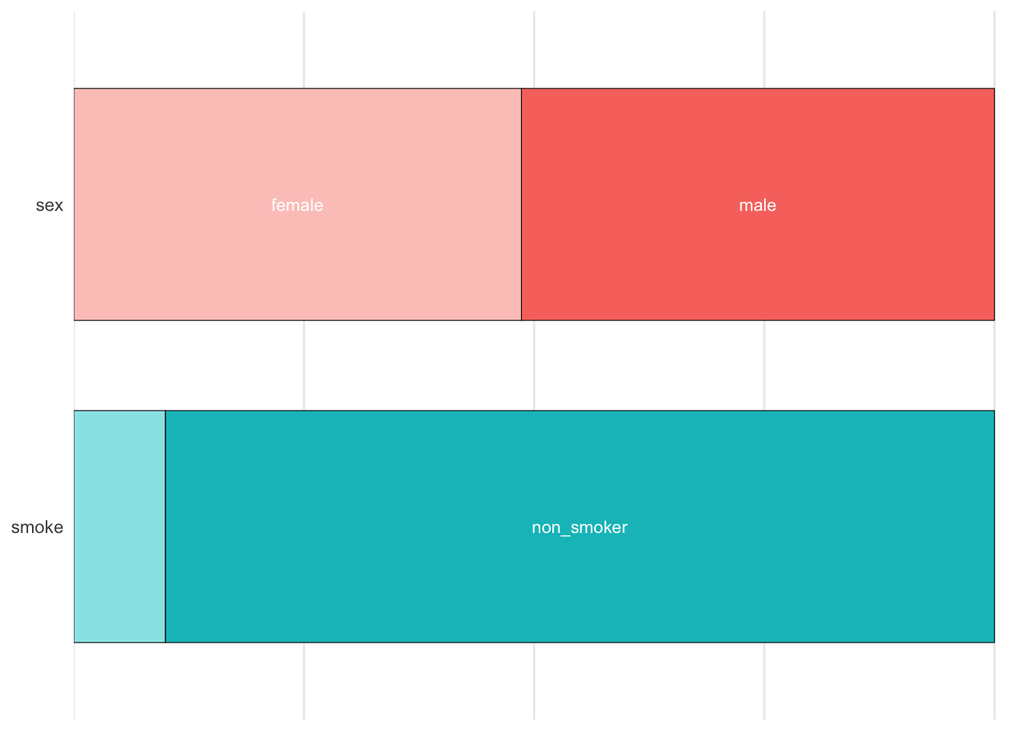

```r
inspect_cat(fev) %>% show_plot()
```

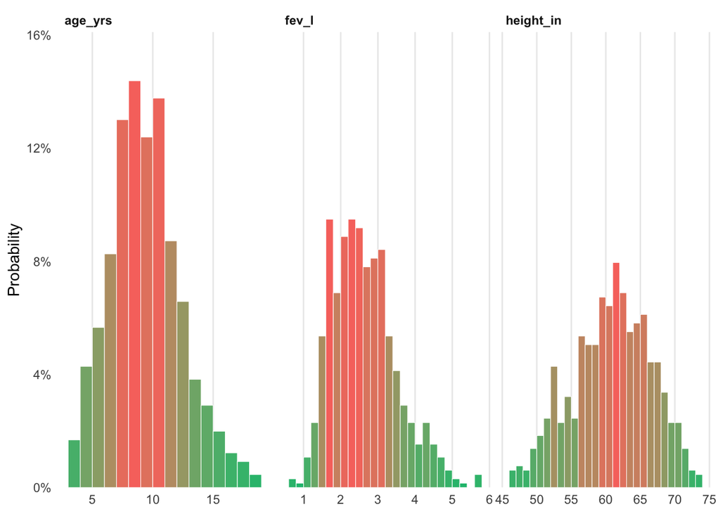

```r
inspect_num(fev) %>% show_plot()
```

**Checkpoint:** `fev` should have **654 rows and 5 columns**.

Question: Which variables are numeric, and which look roughly symmetric?

**Answer:** `fev_l`, `age_yrs`, and `height_in` are numeric. The inspect_num() plots suggest that `height_in` is the most roughly symmetric of the numeric variables. `fev_l` is somewhat right-skewed, and `age_yrs` is discrete and bounded. `smoke` and `sex` are categorical.

## Set the reference levels

`read_csv()` reads `smoke` and `sex` in as plain character columns. When you pass a character column to `lm()`, R silently converts it to a factor and uses the **alphabetically first** level as the reference (baseline) group. Every coefficient is then a comparison *against* that reference.

It is preferred to set the reference levels explicitly, with `factor()` and the `levels` argument. The first level listed becomes the reference.

We want **non-smokers** as the reference for `smoke`, and **females** as the reference for `sex`, so that the coefficients read as “smokers compared to non-smokers” and “males compared to females”.

*Exercise chunk (blank):*

```r
fev <- fev %>%
  mutate(
    smoke = factor(smoke, levels = c("non_smoker", "smoker")),
    sex = factor(sex, levels = c(________, ________))
  )

levels(fev$smoke)
levels(fev$sex)
```

**Solution:**

```r
fev <- fev %>%
  mutate(
    smoke = factor(smoke, levels = c("non_smoker", "smoker")),
    sex = factor(sex, levels = c("female", "male"))
  )

levels(fev$smoke)
```

```
## [1] "non_smoker" "smoker"
```

```r
levels(fev$sex)
```

```
## [1] "female" "male"
```

**Question:** If female is the reference level, what would we expect to see in the model output when we fit a model that includes sex?

1. A row with the coefficient for sexfemale

```
              Estimate [...]
(Intercept)    2.451
sexfemale      0.361      [...]
```

2. A row with the coefficient for sexmale

```
              Estimate [...]
(Intercept)    2.451
sexmale        0.361      [...]
```

Ans:

**Answer:** **B.** When female is the reference level, R does not create a coefficient for `sexfemale`. Instead, it creates an indicator for the non-reference level, `sexmale`, which compares males to females, holding any other variables in the model fixed.

If male were the reference, you would see a `sexfemale` row instead.

# Part 1: Define the effect and the confounding problem

## Part 1a: The raw smoking difference

Start by calculating the mean FEV, mean height, and mean age for smokers and non-smokers.

*Exercise chunk (blank):*

```r
fev %>%
  group_by(_______) %>%
  summarise(
    mean_fev = ___________,
    mean_height = ___________,
    mean_age = ___________
  )
```

**Solution:**

```r
fev %>%
  group_by(smoke) %>%
  summarise(
    mean_fev = mean(fev_l),
    mean_height = mean(height_in),
    mean_age = mean(age_yrs),
    .groups = "drop"
  )
```

```
## # A tibble: 2 × 4
##   smoke      mean_fev mean_height mean_age
##   <fct>         <dbl>       <dbl>    <dbl>
## 1 non_smoker     2.57        60.6     9.53
## 2 smoker         3.28        66.0    13.5
```

**Question:** Which group has higher mean FEV in the raw summary?

Ans:

**Answer:** Smokers have higher mean FEV in the raw summary.

**Question:** Which group is older and taller on average?

Ans:

**Answer:** Smokers are older and taller on average.

We can visualise the FEV difference with a boxplot and jittered points.

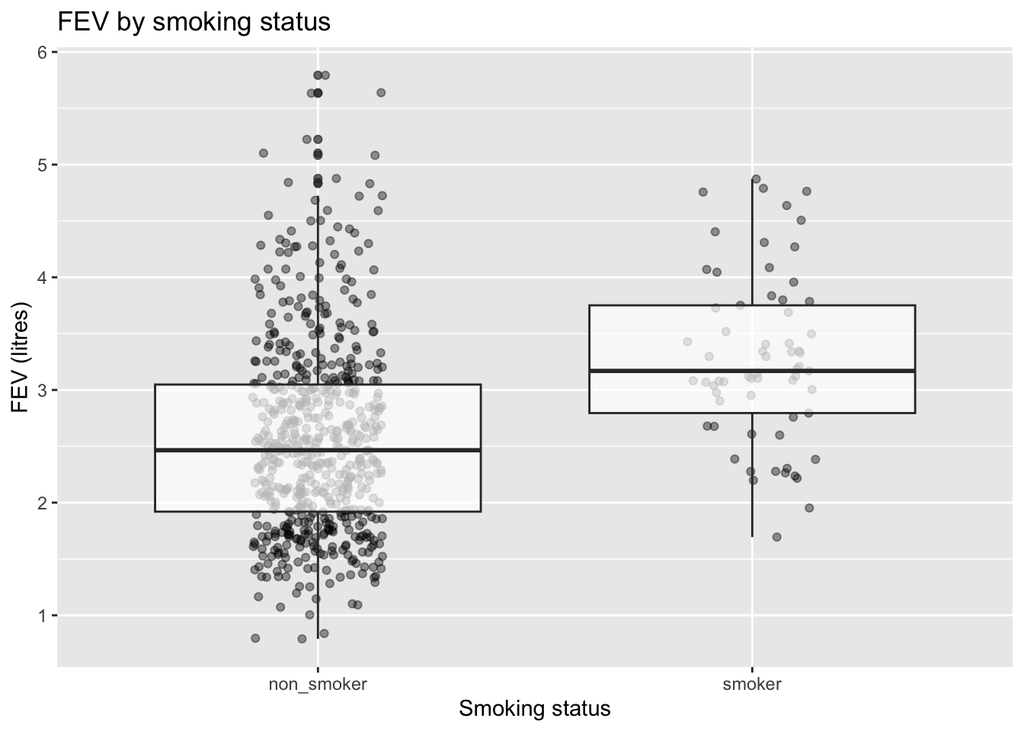

```r
ggplot(fev, aes(x = smoke, y = fev_l)) +
  geom_jitter(width = 0.15, alpha = 0.4) +
  geom_boxplot(alpha = 0.7) +
  labs(
    x = "Smoking status",
    y = "FEV (litres)",
    title = "FEV by smoking status"
  )
```

Let’s now fit a model with smoking as the only predictor.

*Exercise chunk (blank):*

```r
m1_smoke <- ___________
summary(m1_smoke)
```

**Solution:**

```r
m1_smoke <- lm(fev_l ~ smoke, data = fev)
summary(m1_smoke)
```

```
##
## Call:
## lm(formula = fev_l ~ smoke, data = fev)
##
## Residuals:
##     Min      1Q  Median      3Q     Max
## -1.7751 -0.6339 -0.1021  0.4804  3.2269
##
## Coefficients:
##             Estimate Std. Error t value Pr(>|t|)
## (Intercept)  2.56614    0.03466  74.037  < 2e-16 ***
## smokesmoker  0.71072    0.10994   6.464 1.99e-10 ***
## ---
## Signif. codes:  0 '***' 0.001 '**' 0.01 '*' 0.05 '.' 0.1 ' ' 1
##
## Residual standard error: 0.8412 on 652 degrees of freedom
## Multiple R-squared:  0.06023,    Adjusted R-squared:  0.05879
## F-statistic: 41.79 on 1 and 652 DF,  p-value: 1.993e-10
```

**Question:** What is the `smokesmoker` coefficient? Write a one-sentence interpretation of it.

Ans:

**Answer:** The `smokesmoker` coefficient is about **0.711**. In the raw model, smokers have predicted FEV about **0.711 litres higher** than non-smokers, on average.

**Question:** In one sentence, why might the raw comparison be misleading?

Ans:

**Answer:** The raw comparison is misleading because smokers are also older and taller, and older, taller youths naturally have higher FEV.

It can also help to see the equation the model is actually fitting. The `equatiomatic` package does this for you: `extract_eq()` builds the equation from the fitted model, and `preview_eq()` renders it so you can look at it in the RStudio Viewer.

```r
extract_eq(m1_smoke, use_coefs = TRUE) %>% preview_eq()
```

## Part 1b: Confounders and a simple DAG

To estimate the smoking effect cleanly, we want to adjust for **confounders**: variables that might affect both whether a youth smokes and their FEV.

In this dataset, age, height, and sex are all plausible confounders. The DAG below shows this structure:

[figure not shown]

Confounder DAG: age, height, and sex each affect both smoking and FEV

We will therefore want to control for these.

Note that we are deciding these *before* fitting the model(s). This is what modern guidelines recommend: choosing which variables to adjust for ahead of time, based on subject-matter knowledge (including drawing a DAG like the one above), rather than fishing through the variables for significant ones.

That kind of fishing (selecting variables based on their significance in the data) is more defensible when the only goal is to *predict* the outcome as accurately as possible, rather than to *explain* the effect of one particular exposure.

**Answer:** Age, height, and sex are all plausible confounders because each may affect both whether a youth smokes and their FEV. The adjustment set is chosen from the DAG and subject-matter reasoning before fitting the models.

# Part 2: Fit a sequence of adjusted models

In Part 1a, the raw model showed a misleading smoking effect. Now we add confounders one at a time. Each model has the same outcome (`fev_l`).

Write the full `lm()` call for each model.

## Part 2a: Model 2, add age

Age is a plausible confounder because smokers are older on average, and FEV increases strongly with age. Write an lm() call to predict `fev_l` from `smoke` and `age_yrs`.

*Exercise chunk (blank):*

```r
m2_age <- ___________
summary(m2_age)
```

**Solution:**

```r
m2_age <- lm(fev_l ~ smoke + age_yrs, data = fev)
summary(m2_age)
```

```
##
## Call:
## lm(formula = fev_l ~ smoke + age_yrs, data = fev)
##
## Residuals:
##     Min      1Q  Median      3Q     Max
## -1.6653 -0.3564 -0.0508  0.3494  2.0894
##
## Coefficients:
##              Estimate Std. Error t value Pr(>|t|)
## (Intercept)  0.367373   0.081436   4.511 7.65e-06 ***
## smokesmoker -0.208995   0.080745  -2.588  0.00986 **
## age_yrs      0.230605   0.008184  28.176  < 2e-16 ***
## ---
## Signif. codes:  0 '***' 0.001 '**' 0.01 '*' 0.05 '.' 0.1 ' ' 1
##
## Residual standard error: 0.5651 on 651 degrees of freedom
## Multiple R-squared:  0.5766, Adjusted R-squared:  0.5753
## F-statistic: 443.3 on 2 and 651 DF,  p-value: < 2.2e-16
```

**Question:** What happened to the smoking coefficient after adjusting for age?

Ans:

**Answer:** After adjusting for age, the smoking coefficient flips from about **+0.711** to about **-0.209**. The positive raw association was largely explained by smokers being older.

## Part 2b: Model 3, add height

Height is also a plausible confounder because smokers are taller on average, and height is strongly related to lung volume. Add height to the model.

*Exercise chunk (blank):*

```r
m3_age_height <- ___________
summary(m3_age_height)
```

**Solution:**

```r
m3_age_height <- lm(fev_l ~ smoke + age_yrs + height_in, data = fev)
summary(m3_age_height)
```

```
##
## Call:
## lm(formula = fev_l ~ smoke + age_yrs + height_in, data = fev)
##
## Residuals:
##      Min       1Q   Median       3Q      Max
## -1.50182 -0.26305 -0.01882  0.24989  1.98535
##
## Coefficients:
##              Estimate Std. Error t value Pr(>|t|)
## (Intercept) -4.616007   0.223883 -20.618  < 2e-16 ***
## smokesmoker -0.110232   0.060017  -1.837   0.0667 .
## age_yrs      0.059741   0.009563   6.247 7.57e-10 ***
## height_in    0.109095   0.004720  23.115  < 2e-16 ***
## ---
## Signif. codes:  0 '***' 0.001 '**' 0.01 '*' 0.05 '.' 0.1 ' ' 1
##
## Residual standard error: 0.4189 on 650 degrees of freedom
## Multiple R-squared:  0.7676, Adjusted R-squared:  0.7665
## F-statistic: 715.7 on 3 and 650 DF,  p-value: < 2.2e-16
```

**Question:** Interpret the smoking coefficient in this model using the phrase “holding age and height constant.”

Ans:

**Answer:** Holding age and height constant, smokers have predicted FEV about **0.110 litres lower** than non-smokers, on average.

## Part 2c: Model 4, add sex

Finally, add sex. Sex may be related to body size and lung function, and it could also differ between smokers and non-smokers.

*Exercise chunk (blank):*

```r
m4_age_height_sex <- ___________
summary(m4_age_height_sex)
```

**Solution:**

```r
m4_age_height_sex <- lm(fev_l ~ smoke + age_yrs + height_in + sex, data = fev)
summary(m4_age_height_sex)
```

```
##
## Call:
## lm(formula = fev_l ~ smoke + age_yrs + height_in + sex, data = fev)
##
## Residuals:
##      Min       1Q   Median       3Q      Max
## -1.37656 -0.25033  0.00894  0.25588  1.92047
##
## Coefficients:
##              Estimate Std. Error t value Pr(>|t|)
## (Intercept) -4.456974   0.222839 -20.001  < 2e-16 ***
## smokesmoker -0.087246   0.059254  -1.472    0.141
## age_yrs      0.065509   0.009489   6.904 1.21e-11 ***
## height_in    0.104199   0.004758  21.901  < 2e-16 ***
## sexmale      0.157103   0.033207   4.731 2.74e-06 ***
## ---
## Signif. codes:  0 '***' 0.001 '**' 0.01 '*' 0.05 '.' 0.1 ' ' 1
##
## Residual standard error: 0.4122 on 649 degrees of freedom
## Multiple R-squared:  0.7754, Adjusted R-squared:  0.774
## F-statistic:   560 on 4 and 649 DF,  p-value: < 2.2e-16
```

Let’s look at the equation for this one too, and compare it to Model 1.

*Exercise chunk (blank):*

```r
extract_eq(________, use_coefs = TRUE) %>% preview_eq()
```

**Solution:**

```r
extract_eq(m4_age_height_sex, use_coefs = TRUE) %>% preview_eq()
```

**Question:** Again, interpret the smoking coefficient in this model. At alpha = 0.05, is the adjusted smoking coefficient statistically significant in Model 4?

Ans:

**Answer:** Holding age, height, and sex constant, smokers have predicted FEV about **0.087 litres lower** than non-smokers, on average. The p-value is about **0.14**, so at alpha = 0.05 we fail to reject the null hypothesis for the adjusted smoking coefficient.

# Part 3: Compare models side by side

Now, we can put all four models into a list, then use `modelsummary()` to compare them in one table. This shows how the smoking coefficient and model fit change as we add confounders:

```r
model_list <- list(
  "1. Smoking only" = m1_smoke,
  "2. + age" = m2_age,
  "3. + height" = m3_age_height,
  "4. + sex" = m4_age_height_sex
)

modelsummary(
  model_list,
  estimate = "{estimate}",
  statistic = c("[{conf.low}, {conf.high}]", "p = {p.value}"), # two lines under each estimate
  conf_level = 0.95,
  fmt = 3, # decimal places
  coef_map = c(
    "smokesmoker" = "Smoking (smoker vs non-smoker)",
    "age_yrs" = "Age (years)",
    "height_in" = "Height (inches)",
    "sexmale" = "Sex (male vs female)"
  ),
  gof_map = list( # goodness-of-fit statistics to show, and how to label them
    list(raw = "nobs", clean = "N (youths)", fmt = 0),
    list(raw = "r.squared", clean = "R-squared", fmt = 3),
    list(raw = "adj.r.squared", clean = "Adjusted R-squared", fmt = 3)
  ),
  title = "Estimated smoking effect on FEV (litres), by adjustment set",
  notes = "Each cell shows the estimate, the 95% confidence interval, and the p-value. Outcome is FEV in litres.",
  output = "gt" # render as a nicely formatted gt table
)
```

Estimated smoking effect on FEV (litres), by adjustment set

|  | 1. Smoking only | 2. + age | 3. + height | 4. + sex |
| --- | --- | --- | --- | --- |
| Smoking (smoker vs non-smoker) | 0.711 | -0.209 | -0.110 | -0.087 |
|  | [0.495, 0.927] | [-0.368, -0.050] | [-0.228, 0.008] | [-0.204, 0.029] |
|  | p = <0.001 | p = 0.010 | p = 0.067 | p = 0.141 |
| Age (years) |  | 0.231 | 0.060 | 0.066 |
|  |  | [0.215, 0.247] | [0.041, 0.079] | [0.047, 0.084] |
|  |  | p = <0.001 | p = <0.001 | p = <0.001 |
| Height (inches) |  |  | 0.109 | 0.104 |
|  |  |  | [0.100, 0.118] | [0.095, 0.114] |
|  |  |  | p = <0.001 | p = <0.001 |
| Sex (male vs female) |  |  |  | 0.157 |
|  |  |  |  | [0.092, 0.222] |
|  |  |  |  | p = <0.001 |
| N (youths) | 654 | 654 | 654 | 654 |
| R-squared | 0.060 | 0.577 | 0.768 | 0.775 |
| Adjusted R-squared | 0.059 | 0.575 | 0.767 | 0.774 |

Each cell shows the estimate, the 95% confidence interval, and the p-value. Outcome is FEV in litres.

The table reports two related measures of model fit:

- **R-squared** is the proportion of the variation in FEV that the model explains, from 0 to 1. A problem with R-squared is that it can *only go up* when you add a predictor, even if that predictor is useless. So it always rewards bigger models.
- **Adjusted R-squared** fixes this by adding a small penalty for each extra predictor. It only rises if a new predictor improves the fit by more than we would expect from chance. This makes it more honest when comparing models with different numbers of predictors.

**Question:** Look at the R-squared row across the four models. What happens to it as we add predictors, and does the adjusted R-squared behave the same way?

Ans:

**Answer:** R-squared increases sharply from about **0.06** in the smoking-only model to about **0.78** in the final model. Adjusted R-squared behaves the same way here, rising from about **0.06** to about **0.77**, because each confounder we add genuinely improves the fit.

**Question:** Look at the confidence interval for the smoking coefficient in Model 1, and then in Model 4. Does each interval contain zero? Check that your answer agrees with the p-value on the line below it.

Ans:

**Answer:** In Model 1 the smoking interval is **[0.495, 0.927]**, which lies entirely above zero, matching the very small p-value. In Model 4 it is **[-0.204, 0.029]**, which contains zero, matching p = 0.14. The confidence interval and p-value agree because they are computed from the same estimate and standard error.

# Part 4: Report the result

Write a short paragraph reporting the result from the final model.

Begin by stating what the final model adjusted for. Then report the adjusted smoking estimate, its 95% confidence interval. Also report the adjusted R-squared. Use association language rather than cause-and-effect language.

ANSWER:

**Example answer:**

> In the raw comparison, smokers had about **0.71 litres higher** mean FEV than non-smokers, but this comparison does not account for differences in age, height, or sex between the groups. After adjusting for age, height, and sex, smokers had mean FEV about **0.09 litres lower** than non-smokers (95% CI -0.20 to 0.03). This interval includes zero, so the adjusted estimate is compatible with both a small negative association and little or no association in this sample. The final model explained about **77%** of the variation in FEV (adjusted R-squared). Because this is observational data, we describe this as an adjusted association rather than proof that smoking caused lower lung function.

**Marking notes:**

- Learners should state the adjustment set in the same sentence as the smoking estimate.
- The smoking estimate should be in litres with its 95% CI, not just “not significant”.
- An interval that includes zero should be described plainly, not hidden behind p-value language alone.
- Push back on causal wording such as “smoking reduced FEV”. Association language is appropriate here.
- Adjusted R-squared should appear somewhere in the paragraph.
- Learners do not need to report the age, height, or sex coefficients here.

# Optional challenge: Prediction from the adjusted model

Our goal in this workshop was to *explain* the smoking effect, not to build the best possible prediction model. Even so, once we have fitted a regression model, we can also use it to predict FEV for new individuals. If you have time, work through this section.

Use Model 4 to predict FEV for two otherwise similar 12-year-old, 60-inch-tall males: one non-smoker and one smoker.

```r
new_nonsmoker <- tibble(
  smoke = "non_smoker",
  age_yrs = 12,
  height_in = 60,
  sex = "male"
)

predict(m4_age_height_sex, newdata = new_nonsmoker)
```

```
##        1
## 2.738207
```

*Exercise chunk (blank):*

```r
new_smoker <- tibble(
  smoke = "______",
  age_yrs = ______,
  height_in = ______,
  sex = "____"
)

predict(__________, newdata = __________)
```

**Solution:**

```r
new_smoker <- tibble(
  smoke = "smoker",
  age_yrs = 12,
  height_in = 60,
  sex = "male"
)

predict(m4_age_height_sex, newdata = new_smoker)
```

```
##       1
## 2.65096
```

**Question:** How far apart are the two predictions? How does that difference relate to the smoking coefficient in Model 4?

Ans:

**Answer:** The smoker prediction is about **0.087 litres lower** than the non-smoker prediction. That gap matches the smoking coefficient in Model 4 because the two people have the same age, height, and sex.

Extract the coefficients and calculate the smoker prediction by hand.

```r
coef(m4_age_height_sex)
```

```
## (Intercept) smokesmoker     age_yrs   height_in     sexmale
## -4.45697390 -0.08724639  0.06550932  0.10419943  0.15710293
```

*Exercise chunk (blank):*

```r
b <- coef(m4_age_height_sex)

b["(Intercept)"] +
  b["height_in"] * ______ +
  b["age_yrs"] * ______ +
  b["sexmale"] * ______ +
  b["smokesmoker"] * ______
```

**Solution:**

```r
b <- coef(m4_age_height_sex)

b["(Intercept)"] +
  b["height_in"] * 60 +
  b["age_yrs"] * 12 +
  b["sexmale"] * 1 +
  b["smokesmoker"] * 1
```

```
## (Intercept)
##     2.65096
```

**Question:** Does your hand calculation match `predict()`?

Ans:

**Answer:** Yes. It matches the `predict()` result for the 12-year-old, 60-inch-tall male smoker.